# Take At Home Exam

Edouard Dewaerheijd (I6341571)

2023-12-19

# Importing the dataset and librabies

We first started by importing the BankDeposit.cvs dataset and adding necessary packages for later analyses.

```r
BankDeposit <- read.csv("~/GitHub/Maastricht/KDDV/Take at home exam/BankDeposit.csv", stringsAsFactors=TRUE)

library(tidyverse)
library(moments)
library(kableExtra)
library(ggcorrplot)
library(rpart)
library(rpart.plot)
library(C50)
library(class)
library(outliers)
library(caret)
```

# Creation of a random subset

A random subset of 5000 observations was generated from the “BankDeposit” dataset. The seed was set to ensure reproducibility.

```r
set.seed(16)
my_data <- BankDeposit[sample(nrow(BankDeposit), size = 5000),]
```

# The Data

before any further analysis let’s look through our variables and undersatnd them using the head function in R.

```r
head(my_data)
```

```
##      age        job marital education default balance housing loan  contact day
## 3809  54    unknown married   unknown      no     895      no   no cellular   7
## 4923  37 technician  single secondary      no    5436     yes   no cellular   6
## 4011  51 management married  tertiary      no     346      no   no cellular  12
## 4872  30   services  single secondary      no    -158     yes   no cellular  12
## 5396  53     admin.  single secondary      no    2398     yes   no cellular   2
## 942   43 unemployed married  tertiary      no      58     yes   no cellular   9
##      month duration campaign pdays previous poutcome   y
## 3809   oct      335        1    -1        0  unknown yes
## 4923   may        7       11   351        1  failure  no
## 4011   nov      134        2   192        3  failure yes
## 4872   may      426        1   370        2  failure yes
## 5396   aug      317        1   180        2  failure yes
## 942    feb       48        4    -1        0  unknown  no
```

```r
cat("numerical varibles : Age, Balance, Day, duration, campaign, pdays, previous)
")
```

```
## numerical varibles : Age, Balance, Day, duration, campaign, pdays, previous)
```

```r
cat("categorical varibles : job,Marital, Education, Default, Housing, Loan, Contact, month, poutcome, y")
```

```
## categorical varibles : job,Marital, Education, Default, Housing, Loan, Contact, month, poutcome, y
```

We also created a small summary table for all the numerical variables :

```r
numeric_data <- select_if(my_data, is.numeric)

#used "num_cols" to fidure out how big I needed my for loop to be
#num_cols <- ncol(numeric_data)
#num_cols


# initiate some empty vectors in which we can contain our descriptive statistics
s.min = s.max = s.mean = s.med = s.qf = s.qt = s.range = s.iqr = s.skew = c()

# Create a for loop in which it calculates all of the different statistics we are interested in
for (i in 1:7) {
  s.min = c(s.min, min(numeric_data[,i]))
  s.max = c(s.max, max(numeric_data[,i]))
  s.range = c(s.range, s.max[i]-s.min[i])
  s.mean = c(s.mean, mean(numeric_data[,i]))
  s.med = c(s.med, median(numeric_data[,i]))
  s.qf = c(s.qf, quantile(numeric_data[,i],0.25))
  s.qt = c(s.qt, quantile(numeric_data[,i],0.75))
  s.iqr = c(s.iqr, IQR(numeric_data[,i]))
  s.skew = c(s.skew, skewness(numeric_data[,i]))
}

# Combine the vectors of descriptive statistics
stats = rbind.data.frame(s.min, s.max, s.mean, s.med, s.qf, s.qt, s.range, s.iqr,s.skew)
# Insert the row names
rownames(stats) = c("Minimum", "Maximum", "Mean", "Median", "1st Quartile", "3rd Quartile", "Range", "IQR","Skewness")
# Insert the same column names from the data frame
colnames(stats) = colnames(numeric_data)

# Display the table
stats %>% kbl() %>% kable_minimal()
```

|  | age | balance | day | duration | campaign | pdays | previous |
| --- | --- | --- | --- | --- | --- | --- | --- |
| Minimum | 18.0000000 | -3313.000000 | 1.0000000 | 4.000000 | 1.000000 | -1.000000 | 0.00000 |
| Maximum | 86.0000000 | 71188.000000 | 31.0000000 | 3094.000000 | 50.000000 | 871.000000 | 25.00000 |
| Mean | 41.2268000 | 1494.132800 | 15.7790000 | 324.781200 | 2.636000 | 45.391400 | 0.66640 |
| Median | 39.0000000 | 507.000000 | 16.0000000 | 221.000000 | 2.000000 | -1.000000 | 0.00000 |
| 1st Quartile | 32.0000000 | 97.750000 | 8.0000000 | 121.000000 | 1.000000 | -1.000000 | 0.00000 |
| 3rd Quartile | 49.0000000 | 1658.000000 | 21.0000000 | 412.000000 | 3.000000 | -1.000000 | 0.00000 |
| Range | 68.0000000 | 74501.000000 | 30.0000000 | 3090.000000 | 49.000000 | 872.000000 | 25.00000 |
| IQR | 17.0000000 | 1560.250000 | 13.0000000 | 291.000000 | 2.000000 | 0.000000 | 0.00000 |
| Skewness | 0.7476114 | 6.453386 | 0.1036998 | 2.364243 | 4.746849 | 2.591273 | 4.80353 |

This table let’s us see the minimum, maximum, mean, distribution and much more in one glips.

#Generic graphs

## Normal Probability plot

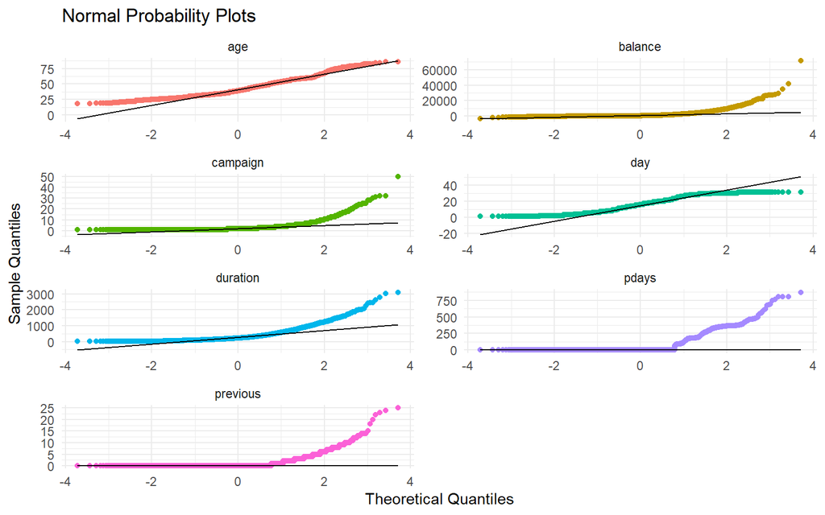

```r
numeric_data_long <- pivot_longer(numeric_data, cols = everything(), names_to = "variable", values_to = "values")

numeric_data_long %>%
  ggplot(aes(sample = values, color = variable)) +
  stat_qq() +
  stat_qq_line(col = "black") +
  facet_wrap(~ variable, ncol = 2, scales = "free") +
  labs(x = "Theoretical Quantiles", y = "Sample Quantiles") +
  ggtitle("Normal Probability Plots") +
  theme_minimal() +
  theme(legend.position = "none")
```

Normal probability plots, also known as QQ plots, allow us to assess visually if the numerical variables in our dataset are normally distributed. The closer the points on the plot are to the diagonal black line, the more the variable is normally distributed. From the QQ plot, we can observe that the variable “Age” is fairly normally distributed. However, the variables “Duration”, “Previous”, “Balance”, “Campaign”, and “Pdays” appear to be skewed (which aligns with the information provided in the summary table above). In conclusion, apart from “Age”, our variables are not normally distributed and exhibit skewness.

## Boxplots

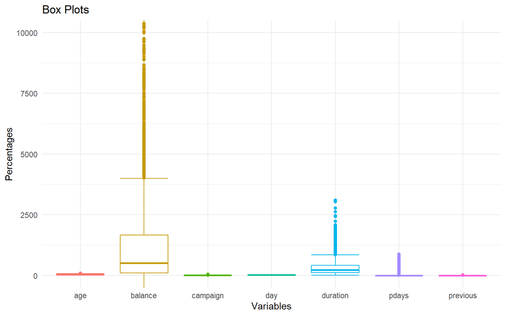

```r
numeric_data_long <- pivot_longer(numeric_data, cols = everything(), names_to = "variable", values_to = "percentages")


numeric_data_long %>% ggplot(aes(y=percentages,x=variable,color=variable)) +
  stat_boxplot(geom ='errorbar') +
  geom_boxplot() +
  labs(x = "Variables", y = "Percentages") +
  ggtitle("Box Plots") + theme_minimal() + theme(legend.position = "none") +
  coord_cartesian(ylim = c(0,10000))
```

Boxplots allow me to further visualize the distribution of each variable. These graphs further confirm that most of the variables are skewed. Furthermore, these graphs show me the distribution, and each little dot above a variable indicates a potential outlier. In the next part of the paper, we will check for outliers mathematically and examine a couple of individual boxplots with noticeable outliers.

# Outliers

## mathematicaly

I used two diffrent methodes to find outliers. firstly I used the Z-score mthode and secondly I used the IQR methode. ### Z-score methode

```r
zscores = sapply(numeric_data[,1:7],FUN = scale)
outliers <-which(zscores > 3 | zscores < -3, arr.ind = T)
str(outliers)
```

```
##  int [1:568, 1:2] 77 88 155 275 384 891 893 1144 1215 1304 ...
##  - attr(*, "dimnames")=List of 2
##   ..$ : NULL
##   ..$ : chr [1:2] "row" "col"
```

```r
#568 outliers using the Z score
```

Using the Z-score method, we found 568 outliers. However, this method assumes that the data follows a normal distribution, and since our data doesn’t strictly follow a normal distribution, this may not be the most effective method to identify outliers. ## IQR methode

```r
#IQR method
outlier_check <- sapply(numeric_data, outlier)
outlier_check
```

```
##      age  balance      day duration campaign    pdays previous
##       86    71188       31     3094       50      871       25
```

## Graphs That Stand Out

### Balance

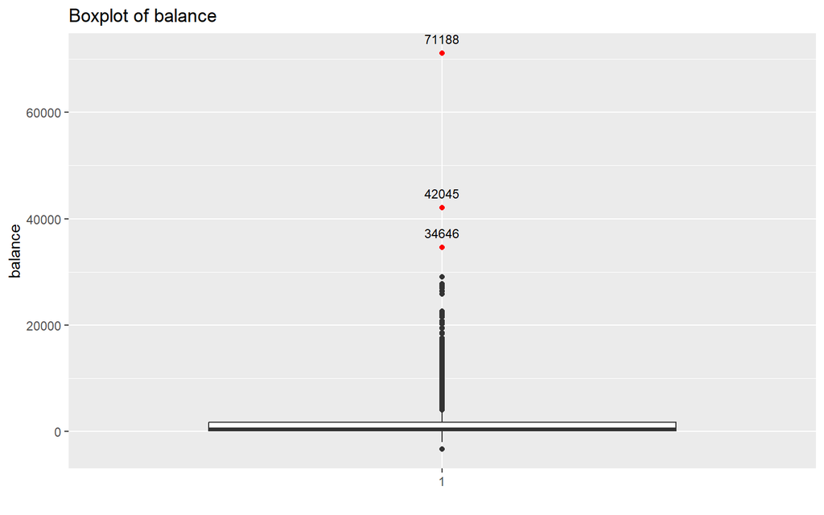

```r
p <- ggplot(numeric_data, aes(x = factor(1), y = balance)) +
  geom_boxplot() +
  ggtitle("Boxplot of balance") +
  labs(x = "", y = "balance")
#find three points
top_outliers <- numeric_data$balance %>%
  sort(decreasing = TRUE) %>%
  head(3)

# Add red points for the top three outliers
p <- p + geom_point(data = numeric_data %>% filter(balance %in% top_outliers),
                    aes(x = factor(1), y = balance),
                    color = "red")
#lables
p <- p + geom_text(data = numeric_data %>% filter(balance %in% top_outliers),
                   aes(x = factor(1), y = balance, label = balance),
                   vjust = -1, size = 3, hjust = 0.5)
p
```

### Duration

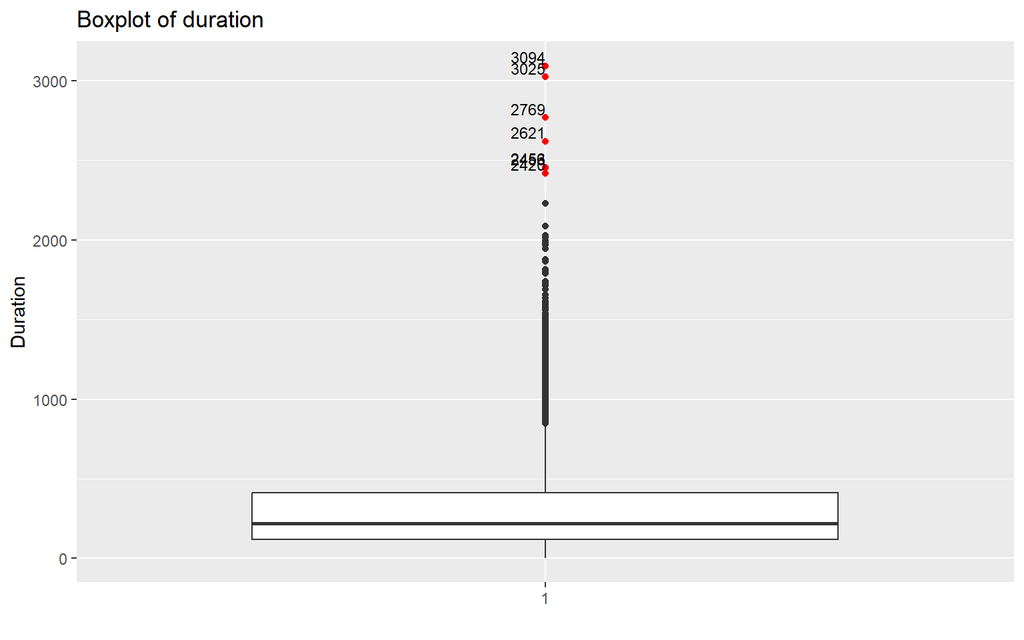

```r
p <- ggplot(numeric_data, aes(x = factor(1), y = duration)) +
  geom_boxplot() +
  ggtitle("Boxplot of duration") +
  labs(x = "", y = "Duration")

top_outliers <- numeric_data$duration %>%
  sort(decreasing = TRUE) %>%
  head(7)
p <- p + geom_point(data = numeric_data %>% filter(duration %in% top_outliers),
                    aes(x = factor(1), y = duration),
                    color = "red")

p <- p + geom_text(data = numeric_data %>% filter(duration %in% top_outliers),
                   aes(x = factor(1), y = duration, label = duration),
                   vjust = -0.25, size = 3, hjust = 1)
p
```

## Conclusion

**getting read of the outliers metioned above from the dataset:**

```r
#getting rid of the outliers

balance_outliers <- my_data$balance %>%
  sort(decreasing = TRUE) %>%
  head(3)

duration_outliers <- my_data$duration %>%
  sort(decreasing = TRUE) %>%
  head(6)

my_data_filtered <- my_data %>%
  filter(!(balance %in% balance_outliers))

my_data_filtered <- my_data_filtered %>%
  filter(!(duration %in% duration_outliers))
```

# Finding Relationships In The Data

## Categorical

### Month

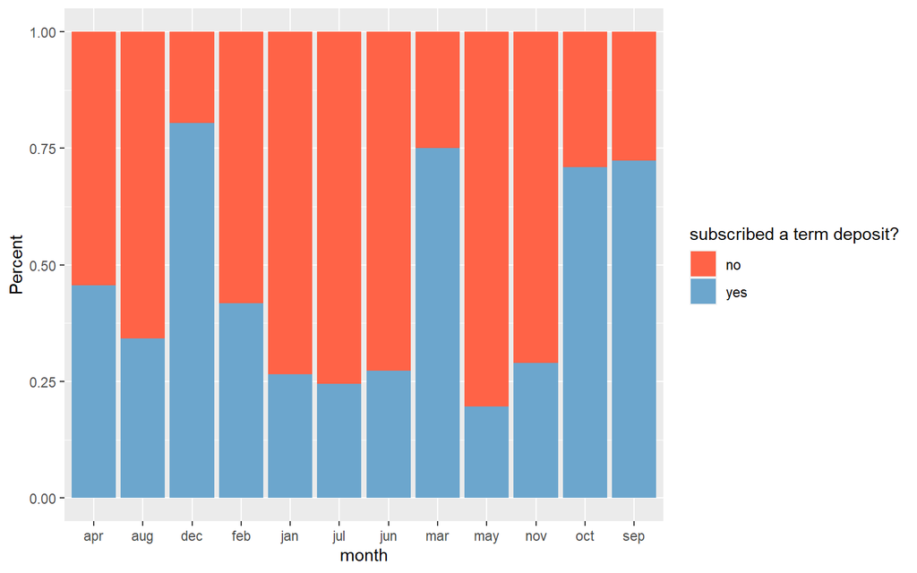

```r
my_data %>% ggplot() +
  geom_bar(aes(month,fill=y),position="fill") +
  scale_x_discrete( "month" ) +
  scale_y_continuous( "Percent" ) +
  guides(fill = guide_legend( title = "subscribed a term deposit?" ) ) +
  scale_fill_manual( values = c( "tomato", "skyblue3" ) )
```

This graph shows the proportion of yes and no of our target variable depending on the month of the last contact. Certain months have a higher proportion of subscriptions than others. In this case, we can see that December, March, October, and September have a higher proportion of “yes” than other months. We can check for exact percentages for each month using a frequency table and a percentage table:

```r
contingency_table <- table(my_data$y, my_data$month)
count_table <- table(my_data$month, my_data$y)
prop_table <- prop.table(count_table, margin = 1) * 100

cat("contingency table")
```

```
## contingency table
```

```r
contingency_table
```

```
##
##        apr  aug  dec  feb  jan  jul  jun  mar  may  nov  oct  sep
##   no   195  471    8  160  119  548  406   26 1120  304   38   29
##   yes  164  245   33  115   43  178  153   78  274  124   93   76
```

```r
cat("percentage table")
```

```
## percentage table
```

```r
prop_table
```

```
##
##             no      yes
##   apr 54.31755 45.68245
##   aug 65.78212 34.21788
##   dec 19.51220 80.48780
##   feb 58.18182 41.81818
##   jan 73.45679 26.54321
##   jul 75.48209 24.51791
##   jun 72.62970 27.37030
##   mar 25.00000 75.00000
##   may 80.34433 19.65567
##   nov 71.02804 28.97196
##   oct 29.00763 70.99237
##   sep 27.61905 72.38095
```

### Poutcome

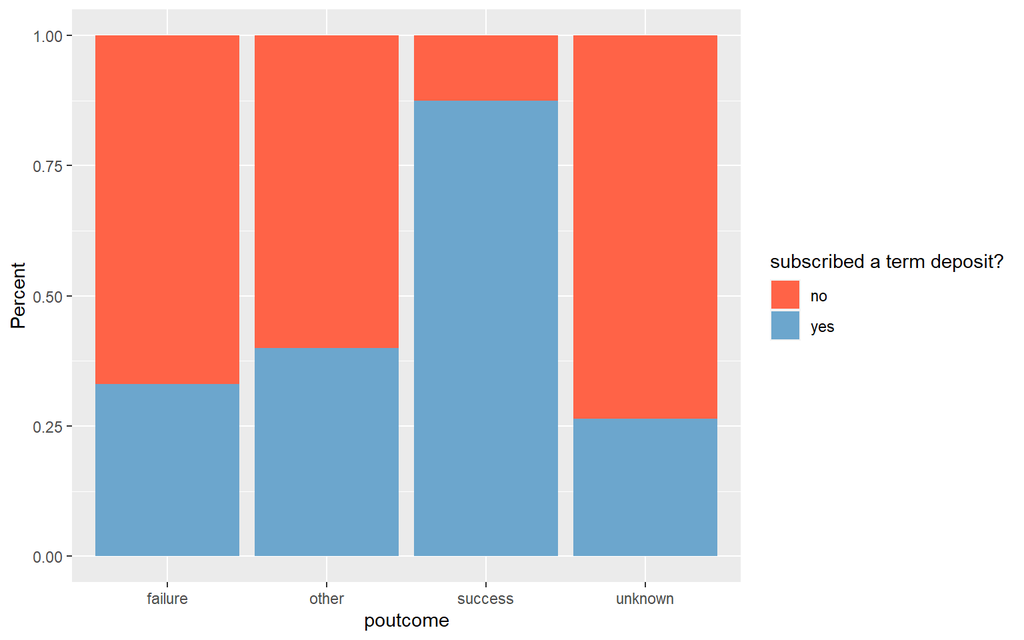

```r
my_data %>% ggplot() +
  geom_bar(aes(poutcome,fill=y),position="fill") +
  scale_x_discrete( "poutcome" ) +
  scale_y_continuous( "Percent" ) +
  guides(fill = guide_legend( title = "subscribed a term deposit?" ) ) +
  scale_fill_manual( values = c( "tomato", "skyblue3" ) )
```

In this graph, we can see the proportion of people subscribing to a term deposit is significantly higher if the outcome of the previous marketing campaign was effective on the potential client. We also created a contingency table to see the exact proportions.

```r
contingency_table <- table(my_data$y, my_data$poutcome)
count_table <- table(my_data$poutcome, my_data$y)
prop_table <- prop.table(count_table, margin = 1) * 100

cat("contingency table")
```

```
## contingency table
```

```r
contingency_table
```

```
##
##       failure other success unknown
##   no      373   138      38    2875
##   yes     184    92     267    1033
```

```r
cat("percentage table")
```

```
## percentage table
```

```r
prop_table
```

```
##
##                 no      yes
##   failure 66.96589 33.03411
##   other   60.00000 40.00000
##   success 12.45902 87.54098
##   unknown 73.56704 26.43296
```

## Numerical varibles

For numerical variables, we will start by creating proportion histograms like with the categorical variables, but we will also try to bin each of these variables to learn more and make our analysis more accessible.

### Privious

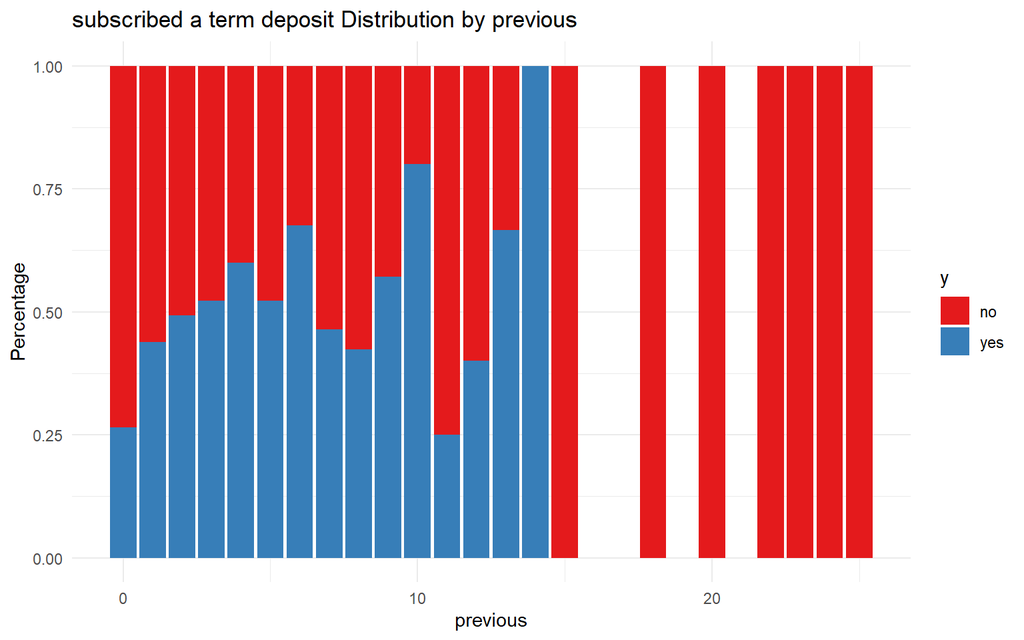

```r
barplot.norm <- function(data, x) {
  variable_name <- deparse(substitute(x))
  graph_title <- paste("subscribed a term deposit Distribution by", variable_name)
  ggplot(data, aes_string(x = variable_name, fill = "y")) +
    geom_bar(position = "fill") +
    labs(title = graph_title,
         x = variable_name,
         y = "Percentage") +
    theme_minimal() +
    scale_fill_brewer(palette = "Set1")
}
barplot.norm(my_data, previous)
```

We can tell that the number of contacts performed before this campaign impacts the potential client’s response to the target variable. We can see that over 15 previous contacts, the answer to the target variable is always no. Let’s try and bin this variable. I decided to bin the variable into two groups, over and under or equal to the median and over the median. The median is 0.

```r
my_data$previous_binned <- ifelse(my_data$previous > 0, "over_median", "at_or_below_median")
table(my_data$previous_binned, my_data$y)
```

```
##
##                        no  yes
##   at_or_below_median 2875 1033
##   over_median         549  543
```

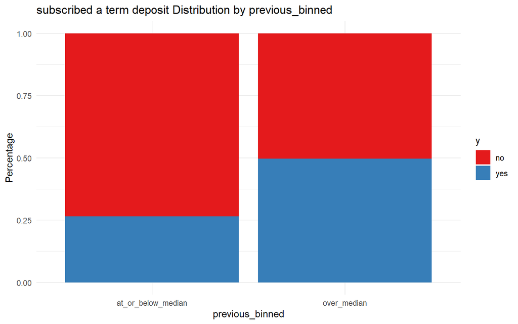

```r
barplot.norm(my_data, previous_binned)
```

We can see a higher proportion of positive responses to our target variable when there was contact in a previous campaign(s).

### Age

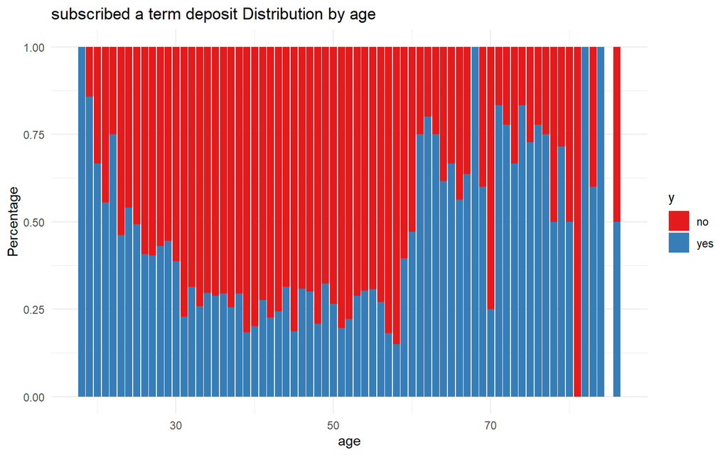

```r
barplot.norm(my_data, age)
```

Let’s divide this variable into three subgroups: young (under 25), middle-aged (working adults from 25 to 65), and old (over 65 and customarily retired).

```r
my_data$age_binned <- ifelse(my_data$age < 25, "young",
                             ifelse(my_data$age <= 65, "middle aged", "old"))

table(my_data$age_binned, my_data$y)
```

```
##
##                 no  yes
##   middle aged 3334 1419
##   old           47   93
##   young         43   64
```

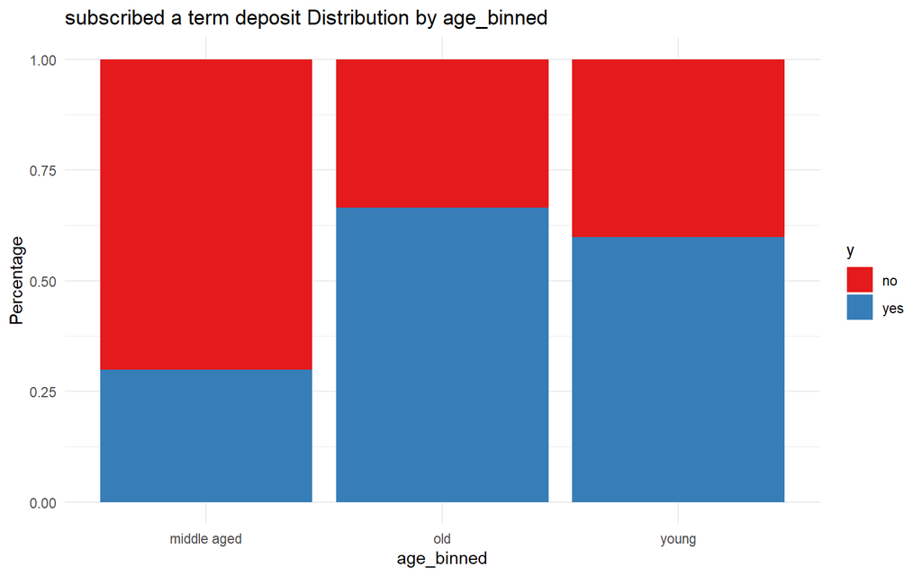

```r
barplot.norm(my_data, age_binned)
```

We can see that the subgroups “old” and “young” proportionally have higher rates of positive answers to our target variable.

# Correlation Testing

```r
corr = cor(numeric_data)
corr
```

```
##                    age       balance          day      duration      campaign
## age       1.0000000000  0.1046784834 -0.018774041 -9.356544e-04 -0.0059540512
## balance   0.1046784834  1.0000000000 -0.003274807  7.225099e-03 -0.0003337098
## day      -0.0187740414 -0.0032748066  1.000000000 -7.930680e-03  0.1495677914
## duration -0.0009356544  0.0072250986 -0.007930680  1.000000e+00 -0.0492588851
## campaign -0.0059540512 -0.0003337098  0.149567791 -4.925889e-02  1.0000000000
## pdays     0.0007602294  0.0025443670 -0.078486279 -1.554650e-02 -0.1017871737
## previous  0.0094666598  0.0240521775 -0.057503230  5.254003e-05 -0.0826478018
##                  pdays      previous
## age       0.0007602294  9.466660e-03
## balance   0.0025443670  2.405218e-02
## day      -0.0784862795 -5.750323e-02
## duration -0.0155465027  5.254003e-05
## campaign -0.1017871737 -8.264780e-02
## pdays     1.0000000000  5.687360e-01
## previous  0.5687360128  1.000000e+00
```

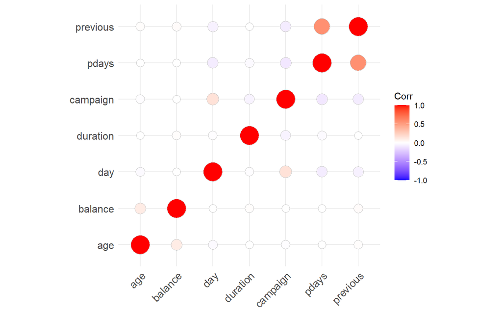

```r
ggcorrplot(corr, method = "circle")
```

After creating a correlation table and a graphical correlation matrix, we can establish that most variables in this dataset are not correlated, except the variables “previous’ and pdays” that are slightly correlated (56% correlated). None of these variables exhibit a sufficient level of correlation to warrant further consideration in the modeling process.

# Data Splitting

```r
#training and testing data
splitIndex <- createDataPartition(my_data_filtered$y, p = 0.7, list = FALSE)

# Creating training and testing datasets
trainData <- my_data_filtered[splitIndex, ]
testData <- my_data_filtered[-splitIndex, ]
```

## Validating the data split

for the following variables (these are the variables we will be using the most in the model-making part), we will be checking if the split is correctly effectuated or if there is a significant difference in distribution between the training and the testing data.

### y (target varible)

```r
success_train <- sum(trainData$y == "yes")
success_test <- sum(testData$y == "yes")
# Total observations in both datasets
n_train <- nrow(trainData)
n_test <- nrow(testData)

# Calculate the proportions
p_train <- success_train / n_train
p_test <- success_test / n_test

# Pooled proportion
p_pooled <- (success_train + success_test) / (n_train + n_test)

# Z-test calculation
z_score <- (p_train - p_test) / sqrt(p_pooled * (1 - p_pooled) * (1/n_train + 1/n_test))
p_value <- 2 * pnorm(-abs(z_score))  # Two-tailed test

# Output the results
list(z_score = z_score, p_value = p_value)
```

```
## $z_score
## [1] -0.006277923
##
## $p_value
## [1] 0.994991
```

The P-value is 0.995. This means we do not have enough evidence to reject the null hypothesis. Thus, we can not conclude that there is a true difference in proportion in the train and test sub-datasets. ### pourcome

```r
length(trainData$y)
```

```
## [1] 3494
```

```r
length(testData$y)
```

```
## [1] 1497
```

```r
length(trainData$y[trainData$y == "yes"])
```

```
## [1] 1099
```

```r
length(testData$y[testData$y == "yes"])
```

```
## [1] 471
```

```r
prop.test( x = c(1099,471) , n=  c(3494,1497), alternative = "two.sided", correct = FALSE)
```

```
##
##  2-sample test for equality of proportions without continuity correction
##
## data:  c(1099, 471) out of c(3494, 1497)
## X-squared = 3.9412e-05, df = 1, p-value = 0.995
## alternative hypothesis: two.sided
## 95 percent confidence interval:
##  -0.02820399  0.02802390
## sample estimates:
##    prop 1    prop 2
## 0.3145392 0.3146293
```

The P-value is 0.995. This means we do not have enough evidence to reject the null hypothesis. Thus, we can not conclude that there is a true difference in proportion in the train and test sub-datasets.

### Age

```r
t.test(trainData$age, testData$age)
```

```
##
##  Welch Two Sample t-test
##
## data:  trainData$age and testData$age
## t = -0.52739, df = 2795.1, p-value = 0.598
## alternative hypothesis: true difference in means is not equal to 0
## 95 percent confidence interval:
##  -0.8781650  0.5059002
## sample estimates:
## mean of x mean of y
##  41.16056  41.34669
```

The P-value is 0.598. This means we do not have enough evidence to reject the null hypothesis. Thus, we can not conclude that there is a true difference in proportion in the train and test sub-datasets. ### Duration

```r
t.test(trainData$duration, testData$duration)
```

```
##
##  Welch Two Sample t-test
##
## data:  trainData$duration and testData$duration
## t = -0.93649, df = 2715.3, p-value = 0.3491
## alternative hypothesis: true difference in means is not equal to 0
## 95 percent confidence interval:
##  -27.878794   9.856558
## sample estimates:
## mean of x mean of y
##  319.1686  328.1797
```

The P-value is 0.3491 This means we do not have enough evidence to reject the null hypothesis. Thus, we can not conclude that there is a true difference in proportion in the train and test sub-datasets.

# Model bulding

## Cart Tree

```r
model <- rpart(y ~ ., data = trainData, method = "class")
printcp(model)
```

```
##
## Classification tree:
## rpart(formula = y ~ ., data = trainData, method = "class")
##
## Variables actually used in tree construction:
## [1] contact  duration housing  month    poutcome
##
## Root node error: 1099/3494 = 0.31454
##
## n= 3494
##
##         CP nsplit rel error  xerror     xstd
## 1 0.168335      0   1.00000 1.00000 0.024974
## 2 0.078253      1   0.83167 0.83803 0.023697
## 3 0.060510      2   0.75341 0.73976 0.022727
## 4 0.020928      4   0.63239 0.63967 0.021562
## 5 0.010000      7   0.56233 0.59236 0.020942
```

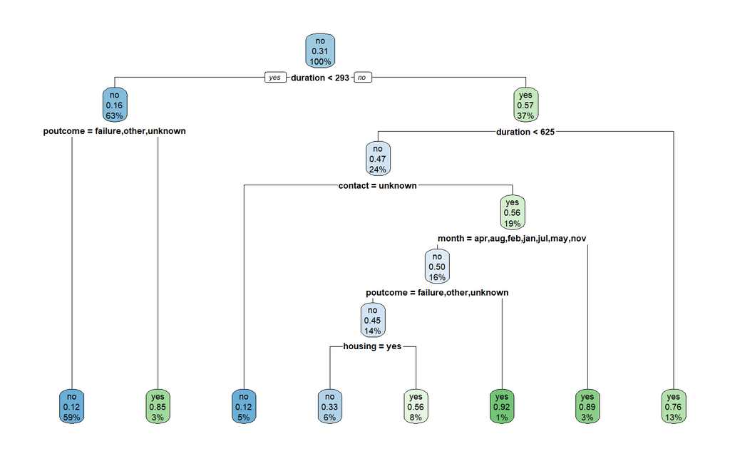

```r
rpart.plot(model)
```

```r
predictions <- predict(model, testData, type = "class")

cm_cart <- confusionMatrix(predictions, testData$y)
cm_cart
```

```
## Confusion Matrix and Statistics
##
##           Reference
## Prediction  no yes
##        no  908 163
##        yes 118 308
##
##                Accuracy : 0.8123
##                  95% CI : (0.7916, 0.8318)
##     No Information Rate : 0.6854
##     P-Value [Acc > NIR] : < 2.2e-16
##
##                   Kappa : 0.5532
##
##  Mcnemar's Test P-Value : 0.008669
##
##             Sensitivity : 0.8850
##             Specificity : 0.6539
##          Pos Pred Value : 0.8478
##          Neg Pred Value : 0.7230
##              Prevalence : 0.6854
##          Detection Rate : 0.6065
##    Detection Prevalence : 0.7154
##       Balanced Accuracy : 0.7695
##
##        'Positive' Class : no
##
```

## C50

```r
trainData$y <- as.factor(trainData$y)

model2 <- C5.0(y ~ ., data = trainData)

summary(model2)
```

```
##
## Call:
## C5.0.formula(formula = y ~ ., data = trainData)
##
##
## C5.0 [Release 2.07 GPL Edition]      Tue Dec 19 22:32:10 2023
## -------------------------------
##
## Class specified by attribute `outcome'
##
## Read 3494 cases (17 attributes) from undefined.data
##
## Decision tree:
##
## poutcome = success: yes (217/28)
## poutcome in {failure,other,unknown}:
## :...duration <= 305:
##     :...pdays > 373:
##     :   :...duration <= 128: no (7/1)
##     :   :   duration > 128: yes (18/2)
##     :   pdays <= 373:
##     :   :...age > 60:
##     :       :...duration <= 143: no (23/4)
##     :       :   duration > 143:
##     :       :   :...contact = unknown: yes (0)
##     :       :       contact = telephone: no (6/2)
##     :       :       contact = cellular:
##     :       :       :...marital in {divorced,married}: yes (31/4)
##     :       :           marital = single: no (2)
##     :       age <= 60:
##     :       :...month in {apr,dec,feb,mar,oct,sep}:
##     :           :...duration <= 80: no (60/1)
##     :           :   duration > 80:
##     :           :   :...housing = yes:
##     :           :       :...month in {apr,dec,feb}: no (106/16)
##     :           :       :   month in {mar,oct,sep}: yes (19/6)
##     :           :       housing = no:
##     :           :       :...day > 8: yes (104/39)
##     :           :           day <= 8:
##     :           :           :...month in {apr,feb,oct,sep}: no (49/9)
```

[output cut: 153 more lines]

```
##   74.27% age
##   60.88% pdays
##   38.81% contact
##   22.95% housing
##   19.49% day
##   16.74% default
##    8.07% job
##    6.07% loan
##    4.32% education
##    3.58% marital
##    1.00% balance
##    0.63% campaign
##
##
## Time: 0.0 secs
```

[figure not shown]

```r
plot(model2)
```

```r
#testData$y <- factor(testData$y, levels = levels(test_predictions))


test_predictions <- predict(model2, newdata = testData)

c50_cm <- confusionMatrix(test_predictions, testData$y)
c50_cm
```

```
## Confusion Matrix and Statistics
##
##           Reference
## Prediction  no yes
##        no  905 110
##        yes 121 361
##
##                Accuracy : 0.8457
##                  95% CI : (0.8264, 0.8636)
##     No Information Rate : 0.6854
##     P-Value [Acc > NIR] : <2e-16
##
##                   Kappa : 0.6444
##
##  Mcnemar's Test P-Value : 0.5106
##
##             Sensitivity : 0.8821
##             Specificity : 0.7665
##          Pos Pred Value : 0.8916
##          Neg Pred Value : 0.7490
##              Prevalence : 0.6854
##          Detection Rate : 0.6045
##    Detection Prevalence : 0.6780
##       Balanced Accuracy : 0.8243
##
##        'Positive' Class : no
##
```

## Logistic Regression

```r
model3 <- step(glm(y ~ ., data = trainData, family = binomial()))
```

```
## Start:  AIC=2656.32
## y ~ age + job + marital + education + default + balance + housing +
##     loan + contact + day + month + duration + campaign + pdays +
##     previous + poutcome
##
##             Df Deviance    AIC
## - previous   1   2570.3 2654.3
## - age        1   2570.4 2654.4
## - balance    1   2570.5 2654.5
## - day        1   2570.7 2654.7
## - pdays      1   2571.4 2655.4
## - default    1   2571.5 2655.5
## <none>           2570.3 2656.3
## - marital    2   2577.6 2659.6
## - loan       1   2581.3 2665.3
## - education  3   2588.0 2668.0
## - job       11   2605.6 2669.6
## - campaign   1   2590.1 2674.1
## - housing    1   2608.5 2692.5
## - contact    2   2652.2 2734.2
## - month     11   2713.1 2777.1
## - poutcome   3   2727.5 2807.5
## - duration   1   3549.4 3633.4
##
## Step:  AIC=2654.33
## y ~ age + job + marital + education + default + balance + housing +
##     loan + contact + day + month + duration + campaign + pdays +
##     poutcome
##
##             Df Deviance    AIC
## - age        1   2570.5 2652.5
## - balance    1   2570.5 2652.5
## - day        1   2570.8 2652.8
## - pdays      1   2571.4 2653.4
## - default    1   2571.5 2653.5
## <none>           2570.3 2654.3
## - marital    2   2577.6 2657.6
## - loan       1   2581.3 2663.3
## - education  3   2588.0 2666.0
## - job       11   2605.6 2667.6
```

[output cut: 87 more lines]

```
## y ~ job + marital + education + housing + loan + contact + month +
##     duration + campaign + poutcome
##
##             Df Deviance    AIC
## <none>           2573.2 2647.2
## - marital    2   2582.1 2652.1
## - loan       1   2583.7 2655.7
## - education  3   2590.8 2658.8
## - job       11   2608.3 2660.3
## - campaign   1   2592.2 2664.2
## - housing    1   2611.8 2683.8
## - contact    2   2656.1 2726.1
## - month     11   2721.6 2773.6
## - poutcome   3   2762.7 2830.7
## - duration   1   3552.5 3624.5
```

```r
summary(model3)
```

```
##
## Call:
## glm(formula = y ~ job + marital + education + housing + loan +
##     contact + month + duration + campaign + poutcome, family = binomial(),
##     data = trainData)
##
## Coefficients:
##                      Estimate Std. Error z value Pr(>|z|)
## (Intercept)        -1.6639632  0.3432952  -4.847 1.25e-06 ***
## jobblue-collar     -0.3717596  0.2107356  -1.764 0.077714 .
## jobentrepreneur    -0.8627805  0.3738516  -2.308 0.021009 *
## jobhousemaid       -0.1252222  0.3606691  -0.347 0.728445
## jobmanagement      -0.2752755  0.2055350  -1.339 0.180469
## jobretired          0.4811272  0.2490934   1.932 0.053420 .
## jobself-employed   -0.3264409  0.2992354  -1.091 0.275310
## jobservices        -0.2808485  0.2351021  -1.195 0.232251
## jobstudent          0.7717467  0.2981393   2.589 0.009638 **
## jobtechnician      -0.2176827  0.1966191  -1.107 0.268238
## jobunemployed      -0.0031566  0.3228966  -0.010 0.992200
## jobunknown         -0.7117689  0.7216823  -0.986 0.324004
## maritalmarried     -0.2847362  0.1663040  -1.712 0.086870 .
## maritalsingle       0.0400415  0.1802854   0.222 0.824236
## educationsecondary  0.3486909  0.1869085   1.866 0.062101 .
## educationtertiary   0.7940969  0.2130275   3.728 0.000193 ***
## educationunknown    0.1346491  0.3062894   0.440 0.660217
## housingyes         -0.7333264  0.1190410  -6.160 7.26e-10 ***
## loanyes            -0.5311610  0.1673201  -3.175 0.001501 **
## contacttelephone   -0.0673075  0.2059092  -0.327 0.743759
## contactunknown     -1.6931558  0.1957353  -8.650  < 2e-16 ***
## monthaug           -0.6232486  0.2092801  -2.978 0.002901 **
## monthdec            0.7950913  0.5374853   1.479 0.139066
## monthfeb           -0.0389632  0.2440334  -0.160 0.873146
## monthjan           -1.3035060  0.3076068  -4.238 2.26e-05 ***
## monthjul           -1.0534730  0.2189544  -4.811 1.50e-06 ***
## monthjun            0.3513958  0.2509850   1.400 0.161493
## monthmar            1.3114021  0.3297568   3.977 6.98e-05 ***
## monthmay           -0.6738199  0.2051579  -3.284 0.001022 **
## monthnov           -0.8043837  0.2276173  -3.534 0.000409 ***
## monthoct            0.7784528  0.3370220   2.310 0.020899 *
## monthsep            0.8866065  0.3616913   2.451 0.014235 *
## duration            0.0053639  0.0002256  23.775  < 2e-16 ***
## campaign           -0.1058980  0.0257932  -4.106 4.03e-05 ***
## poutcomeother       0.6798255  0.2403419   2.829 0.004676 **
## poutcomesuccess     2.7141125  0.2626238  10.335  < 2e-16 ***
## poutcomeunknown     0.0389025  0.1570431   0.248 0.804352
## ---
## Signif. codes:  0 '***' 0.001 '**' 0.01 '*' 0.05 '.' 0.1 ' ' 1
##
## (Dispersion parameter for binomial family taken to be 1)
##
##     Null deviance: 4351.3  on 3493  degrees of freedom
## Residual deviance: 2573.2  on 3457  degrees of freedom
## AIC: 2647.2
##
## Number of Fisher Scoring iterations: 6
```

```r
#test on hold out data
test_predictions <- predict(model3, newdata = testData, type = "response")

test_predictions_binary <- ifelse(test_predictions > 0.5, "yes", "no")

test_predictions_binary <- factor(test_predictions_binary, levels = levels(testData$y))
glm_cm <- confusionMatrix(test_predictions_binary, testData$y)

glm_cm
```

```
## Confusion Matrix and Statistics
##
##           Reference
## Prediction  no yes
##        no  939 167
##        yes  87 304
##
##                Accuracy : 0.8303
##                  95% CI : (0.8103, 0.849)
##     No Information Rate : 0.6854
##     P-Value [Acc > NIR] : < 2.2e-16
##
##                   Kappa : 0.5876
##
##  Mcnemar's Test P-Value : 7.163e-07
##
##             Sensitivity : 0.9152
##             Specificity : 0.6454
##          Pos Pred Value : 0.8490
##          Neg Pred Value : 0.7775
##              Prevalence : 0.6854
##          Detection Rate : 0.6273
##    Detection Prevalence : 0.7388
##       Balanced Accuracy : 0.7803
##
##        'Positive' Class : no
##
```

The next model we created was a logistic regression model using stepwise to find the model that keeps only variables that are significant to the model. This model uses 36 variables but only uses 10 variables from the dataset; the categorical variables with multiple groups are separated into flag variables for each subgroup, which explains the large number of variables. The model ended up with an actuality of 83.03% against the hold-out data. It has a Kappa of 58.76 and a balanced accuracy of 78.03%.

### KNN

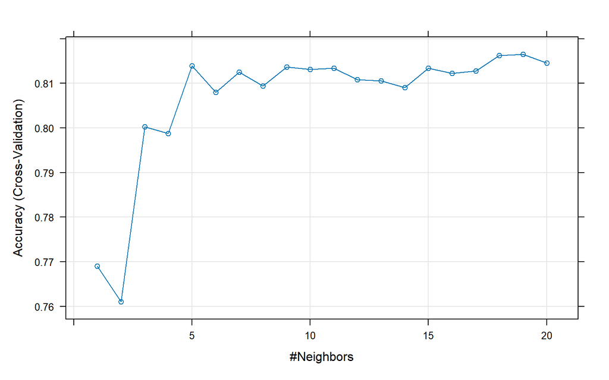

```r
# Normalize continuous variables
normalized_trainData <- trainData
normalized_trainData$age <- scale(trainData$age)
normalized_trainData$duration <- scale(trainData$duration)

# Convert categorical variables to dummy variables
dummies <- model.matrix(~ month + poutcome - 1, data = trainData)
normalized_trainData <- cbind(normalized_trainData[, c("age", "duration")], dummies)


predictors <- normalized_trainData
response <- trainData$y

k_values <- expand.grid(k = 1:20)
train_control <- trainControl(method = "cv", number = 10)

knn_model <- train(x = predictors, y = response, method = "knn", tuneGrid = k_values, trControl = train_control)

plot(knn_model)
```

```r
# Normalize continuous variables in testData
testData$age <- scale(testData$age)
testData$duration <- scale(testData$duration)

# Create dummy variables for categorical variables in testData
dummies_test <- model.matrix(~ month + poutcome - 1, data = testData)
testData_prepared <- cbind(testData[, c("age", "duration")], dummies_test)
#test on hold out data
test_predictions <- predict(knn_model, newdata =  testData_prepared)

knn_cm <- confusionMatrix(test_predictions, testData$y)
knn_cm
```

```
## Confusion Matrix and Statistics
##
##           Reference
## Prediction  no yes
##        no  920 166
##        yes 106 305
##
##                Accuracy : 0.8183
##                  95% CI : (0.7978, 0.8375)
##     No Information Rate : 0.6854
##     P-Value [Acc > NIR] : < 2.2e-16
##
##                   Kappa : 0.5637
##
##  Mcnemar's Test P-Value : 0.000347
##
##             Sensitivity : 0.8967
##             Specificity : 0.6476
##          Pos Pred Value : 0.8471
##          Neg Pred Value : 0.7421
##              Prevalence : 0.6854
##          Detection Rate : 0.6146
##    Detection Prevalence : 0.7255
##       Balanced Accuracy : 0.7721
##
##        'Positive' Class : no
##
```

The K nearest neighbor model has an accuracy of 81.83%, a kappa of 0.5637, and a balanced accuracy of 77.21%.

# model comparaison

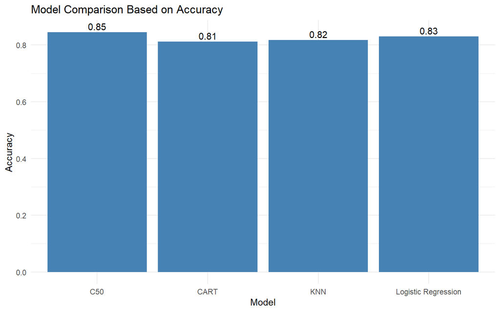

```r
# Assuming cm_cart, c50_cm, glm_cm, and knn_cm are your confusion matrix objects for each model
accuracy_cart <- cm_cart$overall['Accuracy']
accuracy_c50 <- c50_cm$overall['Accuracy']
accuracy_logistic <- glm_cm$overall['Accuracy']
accuracy_knn <- knn_cm$overall['Accuracy']

# Combine into a data frame
model_comparisons <- data.frame(
  Model = c("CART", "C50", "Logistic Regression", "KNN"),
  Accuracy = c(accuracy_cart, accuracy_c50, accuracy_logistic, accuracy_knn)
)

ggplot(model_comparisons, aes(x = Model, y = Accuracy)) +
  geom_bar(stat = "identity", fill = "steelblue") +
  geom_text(aes(label = sprintf("%.2f", Accuracy)),
            position = position_dodge(width = 0.9), vjust = -0.3) +
  theme_minimal() +
  labs(title = "Model Comparison Based on Accuracy",
       x = "Model",
       y = "Accuracy")
```

All our models performed relatively similarly. C50 is the most accurate model, with an accuracy rate of 0.85. if we look at adjusted accuracy rates, we can see that C50 outperforms the Cart model by over 5%. Logistic regression and KNN performed remarkably similarly, with a difference in balanced performance of less than 1%.

# Conclusion

For the modeling phase, we created four models: CART decision tree, C5.0 decision tree, k-nearest neighbor model, and logistic regression model.

# Appendix

**Declaration of Originality: Take Home Exam**

By signing this statement, I hereby acknowledge the submitted Exam

Course code: EBC1045

Course name: Knowledge Discovery and Data Visualization

to be produced independently by me.

By signing this statement, I explicitly declare that I am aware of the fraud sanctions as stated in the Education and Examination Regulations (EERs) of SBE, Maastricht University.

**Place**: Brussels Belgium

**Date**: 18/12/2023 to the 19/12/2023

**First and last name:** Edouard Dewaerheijd

**Study programme**: Business Analytics

**ID number:** I6341571

**Id card number:** 593-0155004-58